# Exploratory Subgroup Identification with ForestSearch: GLM Extension

GBSG Analysis — Poisson-Offset (Incidence Rate Ratio)

Author

Larry F. León

Published

March 24, 2026

# 1 Introduction

This vignette demonstrates the **ForestSearch GLM extension** using the Poisson-offset approach as a built-in sanity check against the Cox proportional hazards model. Under the Poisson-offset approximation:

$$\log\bigl(E[\text{events}]\bigr) = \log(\text{follow-up time}) + \beta_0 + \beta_1 \cdot \text{Treat}$$

the incidence rate ratio (IRR) $\exp(\hat\beta_1)$ approximates the Cox hazard ratio when the baseline hazard is locally constant. This allows direct comparison of GLM-based subgroup identification against the established survival methodology from León et al. (2024).

## 1.1 GLM Effect Measure: IRR

| Property | Cox (reference) | Poisson-offset (GLM) |
| --- | --- | --- |
| Estimand | Hazard ratio | Incidence rate ratio |
| Scale | $\exp(\hat\beta)$ | $\exp(\hat\beta)$ |
| Outcome | Time-to-event + censoring | Binary event indicator |
| Offset | None | $\log(\text{follow-up time})$ |
| `outcome_type` | `"survival"` (default) | `"binary"` |
| `effect_measure` | Not specified | `"IRR"` |

# 2 Setup

## 2.1 Load Required Packages

```r
devtools::document(quiet = TRUE)
devtools::load_all(".", quiet = TRUE)

library(survival)
library(data.table)
library(ggplot2)
library(gt)
library(grf)
library(policytree)
library(doFuture)
library(patchwork)

# GLM estimator closures (not yet graduated to R/)
source("dev/glm/glm_effect_estimators.R")

theme_set(theme_minimal(base_size = 12))
```

# 3 Data: German Breast Cancer Study Group Trial

## 3.1 Study Background

The GBSG trial evaluated hormonal treatment (tamoxifen) versus chemotherapy in node-positive breast cancer patients. Key characteristics:

- **Sample size**: N = 686
- **Outcome**: Recurrence-free survival time
- **Censoring rate**: ~56%
- **Treatment**: Hormonal therapy (tamoxifen) vs. chemotherapy

## 3.2 Data Preparation

```r
df.analysis <- survival::gbsg

df.analysis <- within(df.analysis, {
  id          <- seq_len(nrow(df.analysis))
  time_months <- rfstime / 30.4375
  grade3      <- ifelse(grade == "3", 1, 0)
  treat       <- hormon
})

confounders.name <- c("age", "meno", "size", "grade3", "nodes", "pgr", "er")
id.name          <- "id"
treat.name       <- "hormon"

# Survival outcome (for Cox reference)
outcome.name.surv <- "time_months"
event.name        <- "status"

# GLM Poisson-offset outcome
outcome.name.glm  <- "status"        # binary event indicator
offset.name       <- "time_months"   # follow-up time as offset

cat("Sample size:", nrow(df.analysis), "\n")
```

```
#> Sample size: 686
```

```r
cat("Events:", sum(df.analysis[[event.name]]),
    sprintf("(%.1f%%)\n", 100 * mean(df.analysis[[event.name]])))
```

```
#> Events: 299 (43.6%)
```

```r
cat("Baseline factors:", paste(confounders.name, collapse = ", "), "\n")
```

```
#> Baseline factors: age, meno, size, grade3, nodes, pgr, er
```

## 3.3 ITT Effect Comparison

```r
# Cox HR
cox_itt <- coxph(Surv(time_months, status) ~ hormon, data = df.analysis)

# Poisson IRR
pois_itt <- glm(status ~ hormon, family = poisson(link = "log"),
                offset = log(time_months), data = df.analysis)

cat("ITT Treatment Effect:\n")
```

```
#> ITT Treatment Effect:
```

```r
cat("  Cox  log-HR: ", round(coef(cox_itt)["hormon"], 4),
    " (HR =", round(exp(coef(cox_itt)["hormon"]), 3), ")\n")
```

```
#>   Cox  log-HR:  -0.364  (HR = 0.695 )
```

```r
cat("  Pois log-IRR:", round(coef(pois_itt)["hormon"], 4),
    " (IRR =", round(exp(coef(pois_itt)["hormon"]), 3), ")\n")
```

```
#>   Pois log-IRR: -0.3556  (IRR = 0.701 )
```

```r
cat("  Difference:  ", round(coef(pois_itt)["hormon"] - coef(cox_itt)["hormon"], 4), "\n")
```

```
#>   Difference:   0.0084
```

# 4 Parallel Processing Configuration

```r
n_cores <- max(1L, parallel::detectCores(logical = FALSE) - 1L)
n_cores_total <- parallel::detectCores()
cat("Using", n_cores, "of", n_cores_total, "total cores\n")
```

```
#> Using 13 of 14 total cores
```

```r
# Sequential for load_all() compatibility; switch to multisession
# after devtools::install()
par_args <- list(
  plan         = "sequential",
  workers      = n_cores,
  show_message = TRUE
)
```

# 5 Preliminary Analysis: GRF Candidate Selection

## 5.1 GRF Sign Convention for Adverse Outcomes

`causal_forest` estimates `E[Y(1) - Y(0) | X]` where higher Y is implicitly better. Since our binary outcome is adverse (event = bad), the `adverse_outcome = TRUE` flag (default for binary outcomes) flips the outcome to `1 - Y` internally so that the harm-detection sign convention aligns with `causal_survival_forest`.

## 5.2 GRF with Multiple `dmin.grf` Thresholds

The `dmin.grf` parameter gates on the minimum doubly-robust score difference within a policy tree leaf node. For binary outcomes, this is on the probability scale. We explore how different thresholds affect GRF subgroup identification.

### 5.2.1 Cox Reference (RMST-based)

```r
t0 <- proc.time()

grf_cox <- grf.subg.harm.survival(
  data = df.analysis,
  confounders.name = confounders.name,
  outcome.name = outcome.name.surv,
  event.name = event.name,
  id.name = id.name,
  treat.name = treat.name,
  maxdepth = 2,
  n.min = 60,
  dmin.grf = 12,
  frac.tau = 0.6,
  details = TRUE,
  return_selected_cuts_only = FALSE
)
```

```
#> tau, maxdepth = 46.75811 2
#>    leaf.node control.mean control.size control.se depth
#> 1          2         6.49        82.00       3.34     1
#> 2          3        -4.10       604.00       1.06     1
#> 11         4        -7.90       112.00       2.81     2
#> 21         5         3.85       177.00       1.87     2
#> 4          7        -5.89       356.00       1.33     2
#>
#> Selected subgroup:
#>   leaf.node control.mean control.size control.se depth
#> 1         2         6.49        82.00       3.34     1
#>
#> GRF subgroup found
#> Terminating node at max.diff (sg.harm.id):
#> [1] "er <= 0"
#>
#> All splits (from all trees):
#> [1] "er <= 0"   "age <= 50" "age <= 43"
```

```r
timings$grf_cox <- (proc.time() - t0)["elapsed"]

cat("\nCox GRF cuts:", paste(grf_cox$tree.cuts, collapse = ", "), "\n")
```

```
#>
#> Cox GRF cuts: er <= 0, age <= 50, age <= 43
```

```r
if (!is.null(grf_cox$sg.harm.id)) {
  cat("Cox GRF subgroup:", paste(grf_cox$sg.harm.id, collapse = " & "), "\n")
}
```

```
#> Cox GRF subgroup: er <= 0
```

```r
par(mfrow = c(1, 2))
plot(grf_cox$tree1, leaf.labels = c("Control", "Treat"), main = "Cox: Depth 1")
```

[interactive chart not shown]

```r
plot(grf_cox$tree2, leaf.labels = c("Control", "Treat"), main = "Cox: Depth 2")
```

[interactive chart not shown]

```r
par(mfrow = c(1, 1))
```

### 5.2.2 GLM (Binary) with `dmin.grf` Sweep

```r
dmin_values <- c(0.00, 0.01, 0.025, 0.05, 0.075, 0.10, 0.15, 0.20)

cat("=== GRF GLM dmin.grf sweep (adverse_outcome = TRUE) ===\n\n")
```

```
#> === GRF GLM dmin.grf sweep (adverse_outcome = TRUE) ===
```

```r
cat(sprintf("  %-10s  %-15s  %-8s  %s\n",
            "dmin.grf", "Subgroup", "N cuts", "Cuts"))
```

```
#>   dmin.grf    Subgroup         N cuts    Cuts
```

```r
cat("  ", paste(rep("-", 70), collapse = ""), "\n")
grf_glm_results <- list()

for (d in dmin_values) {
  res <- tryCatch(
    grf.subg.harm.glm(
      data = df.analysis,
      confounders.name = confounders.name,
      outcome.name = outcome.name.glm,
      treat.name = treat.name,
      id.name = id.name,
      n.min = 60,
      dmin.grf = d,
      RCT = TRUE,
      maxdepth = 2,
      seedit = 8316951,
      return_selected_cuts_only = FALSE,
      adverse_outcome = TRUE,
      details = FALSE
    ),
    error = function(e) NULL
  )

  grf_glm_results[[as.character(d)]] <- res

  found <- !is.null(res) && !is.null(res$sg.harm.id) &&
           length(res$sg.harm.id) > 0 && !all(is.na(res$sg.harm.id))

  if (found) {
    sg <- paste(res$sg.harm.id, collapse = " & ")
    nc <- length(res$tree.cuts)
    cuts <- paste(res$tree.cuts, collapse = ", ")
    cat(sprintf("  %-10.3f  %-15s  %-8d  %s\n", d, sg, nc, cuts))
  } else {
    cat(sprintf("  %-10.3f  %-15s  %-8s  %s\n", d, "(none)", "-", "-"))
  }
}
```

```
#>   0.000       age <= 43        3         age <= 50, age <= 43, size <= 39
#>   0.010       age <= 43        3         age <= 50, age <= 43, size <= 39
#>   0.025       age <= 43        3         age <= 50, age <= 43, size <= 39
#>   0.050       age <= 43        3         age <= 50, age <= 43, size <= 39
#>   0.075       age <= 43        3         age <= 50, age <= 43, size <= 39
#>   0.100       age <= 43        3         age <= 50, age <= 43, size <= 39
#>   0.150       age <= 43        3         age <= 50, age <= 43, size <= 39
#>   0.200       (none)           -         -
```

### 5.2.3 GRF Comparison Table

```r
grf_summary <- data.frame(
  dmin.grf = dmin_values,
  Subgroup = vapply(dmin_values, function(d) {
    res <- grf_glm_results[[as.character(d)]]
    found <- !is.null(res) && !is.null(res$sg.harm.id) &&
             length(res$sg.harm.id) > 0 && !all(is.na(res$sg.harm.id))
    if (found) paste(res$sg.harm.id, collapse = " & ") else "(none)"
  }, character(1)),
  N_cuts = vapply(dmin_values, function(d) {
    res <- grf_glm_results[[as.character(d)]]
    if (!is.null(res$tree.cuts)) length(res$tree.cuts) else 0L
  }, integer(1))
)

gt(grf_summary) |>
  tab_header(
    title = md("**GRF Subgroup Selection by `dmin.grf`**"),
    subtitle = "causal_forest with adverse_outcome = TRUE"
  ) |>
  cols_label(
    dmin.grf = "dmin.grf",
    Subgroup = "Identified Subgroup",
    N_cuts   = "N Cuts"
  )
```

**GRF Subgroup Selection by `dmin.grf`**

causal_forest with adverse_outcome = TRUE

| dmin.grf | Identified Subgroup | N Cuts |
| --- | --- | --- |
| 0.000 | age <= 43 | 3 |
| 0.010 | age <= 43 | 3 |
| 0.025 | age <= 43 | 3 |
| 0.050 | age <= 43 | 3 |
| 0.075 | age <= 43 | 3 |
| 0.100 | age <= 43 | 3 |
| 0.150 | age <= 43 | 3 |
| 0.200 | (none) | 0 |

**NoteInterpreting the `dmin.grf` Sweep**

- **`dmin.grf = 0`**: Any positive treatment harm qualifies. Most permissive — GRF may find subgroups driven by noise.
- **`dmin.grf = 0.05`**: Requires ≥ 5 percentage-point difference in event probability. A clinically meaningful threshold for many binary outcomes.
- **Higher values**: Increasingly restrictive; may miss real subgroups with moderate effects. In the GBSG data, the binary outcome (event at censoring) has weaker signal than the survival RMST, so the threshold at which GRF stops finding subgroups is informative.

The Cox reference uses `dmin.grf = 12` on the RMST scale (months).

# 6 ForestSearch Analysis

## 6.1 Parameter Mapping

| Parameter | Cox | Poisson-offset | Notes |
| --- | --- | --- | --- |
| `hr.threshold` | 1.25 | 1.25 | Converted to log(1.25) internally |
| `hr.consistency` | 1.0 | 1.0 | Converted to log(1.0) = 0 internally |
| `dmin.grf` | 12 (RMST, months) | 0.0 (probability) | Scale-specific; default auto-resolved |
| `d0.min` / `d1.min` | Min events per arm | Min subjects per arm | Repurposed for GLM |
| `use_grf` | `TRUE` | `TRUE` | Uses `causal_forest` for GLM |
| `use_lasso` | `TRUE` | `TRUE` | Uses `family = "poisson"` for GLM |
| `conf_force` | `c("er <= 0")` | `c("er <= 0")` | Same forced confounders |

## 6.2 Running ForestSearch (Poisson-Offset)

```r
t0 <- proc.time()

fs_pois <- forestsearch(
  df.analysis,
  confounders.name = confounders.name,
  conf_force       = c("er <= 0"),
  outcome.name     = outcome.name.glm,
  event.name       = outcome.name.glm,
  treat.name       = treat.name,
  id.name          = id.name,
  # GLM specification
  outcome_type     = "binary",
  effect_measure   = "IRR",
  offset.name      = offset.name,
  # Threshold parameters
  hr.threshold           = 1.25,
  hr.consistency         = 1.0,
  pconsistency.threshold = 0.80,
  stop_threshold         = 0.80,
  # Search configuration
  sg_focus             = "hr",
  max_subgroups_search = 3,
  use_twostage         = TRUE,
  # Factor selection
  use_grf                   = TRUE,
  return_selected_cuts_only = TRUE,
  use_lasso                 = TRUE,
  cut_type                  = "default",
  dmin.grf                  = 0.0,    # probability scale for GLM
  # Subgroup constraints
  maxk   = 2,
  n.min  = 60,
  d0.min = 12,
  d1.min = 12,
  # Consistency evaluation
  fs.splits = 100,
  # Parallel processing
  parallel_args = par_args,
  # Output options
  showten_subgroups = TRUE,
  details           = TRUE,
  plot.sg           = FALSE
)
```

```
#> GLM mode: outcome_type = binary , effect_measure = IRR
#>   Screening threshold: 0.2231436
#>   Consistency threshold: 0
#>   dmin.grf: 0
#> Forced confounders: er <= 0
#> GRF subgroup: age <= 43
#> GRF cuts identified: 3
#>   Cuts: age <= 50, age <= 43, size <= 39
#> Cox-LASSO selected: 5 of 8 candidate factors
#>   Omitted: age, meno, er
#> Candidate factors: 17
#>  [1] "age <= 50"    "age <= 43"    "size <= 39"   "er <= 0"      "size <= 29.3"
#>  [6] "size <= 25"   "size <= 20"   "size <= 35"   "nodes <= 5"   "nodes <= 3"
#> [11] "nodes <= 1"   "nodes <= 7"   "pgr <= 110"   "pgr <= 32.5"  "pgr <= 7"
#> [16] "pgr <= 131.8" "grade3"
#> Number of possible configurations (<= maxk): maxk = 2 , # combinations = 595
#> Events criteria: control >= 12 , treatment >= 12
#> Sample size criteria: n >= 60
#> Subgroup search completed in 0.01 minutes
#>
#> --- Filtering Summary ---
#>   Combinations evaluated: 595
#>   Passed variance check: 555
#>   Passed prevalence (>= 0.025 ): 555
#>   Passed redundancy check: 530
#>   Passed event counts (d0>= 12 , d1>= 12 ): 489
#>   Passed sample size (n>= 60 ): 448
#>   Cox model fit successfully: 448
#>   Passed HR threshold (>= 0.2231436 ): 15
#> -------------------------
#>
#> Found 15 subgroup candidate(s)
#> # of candidate subgroups (meeting all criteria) = 15
#> Removed 1 near-duplicate subgroups
#> # of unique initial candidates: 14
#> # Restricting to top stop_Kgroups = 3
#> # of candidates to evaluate: 3
#> # Early stop threshold: 0.8
#>
#> ================================================================================
#> TOP 3 CANDIDATE SUBGROUPS FOR CONSISTENCY EVALUATION
#> Sorted by: hr
#> ================================================================================
#>
#> Rank   HR        N       Events  K    Subgroup Definition
#> --------------------------------------------------------------------------------
#> 1      0.813     61      61      2    {er <= 0} & {size <= 35}
#> 2      0.779     79      79      2    {pgr <= 110} & {er <= 0}
#> 3      0.773     75      75      2    {pgr <= 32.5} & {er <= 0}
#> --------------------------------------------------------------------------------
```

```
#> Parallel config: workers = 13 , batch_size = 1
#> Batch 1 / 3 : candidates 1 - 1
#>
#> ==================================================
#> EARLY STOP TRIGGERED (batch 1 )
#>   Candidate: 1 of 3
#>   Pcons: 0.97 >= 0.8
#> ==================================================
#>
#> Evaluated 1 of 3 candidates (early stop)
#> 1 subgroups passed consistency threshold
#> SG focus = hr
#> Seconds and minutes forestsearch overall = 1.079 0.018
#> Consistency algorithm used: twostage
#> Subgroup identified: {er <= 0} & {size <= 35}
```

```r
plan("sequential")
timings$forestsearch <- (proc.time() - t0)["elapsed"]

cat("\nForestSearch (Poisson-offset) completed in",
    round(timings$forestsearch, 1), "seconds\n")
```

```
#>
#> ForestSearch (Poisson-offset) completed in 1.1 seconds
```

## 6.3 ForestSearch Results

### 6.3.1 Identified Subgroups

```r
res_tabs <- sg_tables(fs_pois, ndecimals = 3, which_df = "est")
res_tabs$sg10_out
```

**Identified Subgroups**

Two-factor subgroups (maxk=2)

| Factor 1 | Factor 2 | N | n(C+T) | n<sub>1</sub> | IRR | P<sub>cons</sub> |
| --- | --- | --- | --- | --- | --- | --- |
| {er <= 0} | {size <= 35} | 61 | 61 | 23 | 2.254 | 0.970 |

**Search Configuration:** Single-factor candidates (L) = 34; Maximum combinations evaluated = 595; Search depth (maxk) = 2  
**Search Results:** Candidate subgroups found = 15; Maximum HR estimate = 0.81  
**Note:** E<sub>1</sub> = events in treatment arm; P<sub>cons</sub> = consistency proportion

### 6.3.2 Treatment Effect Estimates

```r
res_tabs$tab_estimates
```

**Treatment Effect Estimates**

Training data estimates

| Subgroup | n | n1 | Rate(C) | Rate(T) | IRR (95% CI) |
| --- | --- | --- | --- | --- | --- |
| ITT | 686 (100.0%) | 246 (35.9%) | 46.6% | 38.2% | 0.70 (0.55, 0.89) |
| Questionable<sup>1</sup> | 61 (8.9%) | 23 (37.7%) | 50.0% | 65.2% | 2.25 (1.13, 4.50) |
| Recommend | 625 (91.1%) | 223 (35.7%) | 46.3% | 35.4% | 0.62 (0.48, 0.80) |

<sup>1</sup> **Identified subgroup** : {er <= 0} & {size <= 35}

### 6.3.3 Identified Subgroup Definition

```r
cat("Identified subgroup (H):", paste(fs_pois$sg.harm, collapse = " & "), "\n")
```

```
#> Identified subgroup (H): {er <= 0} & {size <= 35}
```

```r
cat("Subgroup size:", sum(fs_pois$df.est$treat.recommend == 0),
    sprintf("(%.1f%% of ITT)\n",
            100 * mean(fs_pois$df.est$treat.recommend == 0)))
```

```
#> Subgroup size: 61 (8.9% of ITT)
```

# 7 Bootstrap Bias Correction

## 7.1 Rationale

The GLM effect estimates from identified subgroups are **upwardly biased** due to the selection process, just as Cox HRs are. The same bootstrap bias correction framework applies:

$$\hat\theta_{\text{adj}} = 2\hat\theta_{\text{obs}} - (\hat\theta_{*} + \hat\theta^*_{*} - \hat\theta^*_{\text{obs}})$$

where $\hat\theta$ is the log-IRR (or any GLM effect estimate).

## 7.2 Running Bootstrap Analysis

```r
# Use 500–2000 for production; reduced here for the vignette
NB <- 100

t0 <- proc.time()

fs_bc <- forestsearch_bootstrap_dofuture(
  fs.est        = fs_pois,
  nb_boots      = NB,
  show_three    = FALSE,
  details       = TRUE,
  parallel_args = par_args
)
```

```
#> Ystar matrix generated should be 'boots x N': 100 x 686
#>
#> ForestSearch parameters for bootstrap iterations:
#>   - sg_focus: hr
#>   - maxk: 2
#>   - fs.splits: 100
#>   - max_subgroups_search: 3
#>   - hr.threshold: 1.25
#>   - hr.consistency: 1
#>   - pconsistency.threshold: 0.8
#>   - n.min: 60
#>   - use_twostage: TRUE
#>   - use_lasso: TRUE
#>   - use_grf: TRUE
#>   Bootstrap-specific overrides:
#>   - grf_res: NULL (forces re-selection)
#>   - grf_cuts: NULL (forces re-selection)
#>   - parallel_args: sequential (prevents nested parallelism)
#>   - details: FALSE (suppressed in workers)
#>   - plot.sg: FALSE
#>   - plot.grf: FALSE
```

```
#>
#> === Bootstrap Analysis Complete ===
#> Success rate: 97.0% (97/100)
#>
#> H (Questionable) Estimates:
#>   Unadjusted:       2.25 (1.13,4.5)
#>   Bias-corrected:  1.82 (0.69,4.77)
#>
#> Hc (Recommend) Estimates:
#>   Unadjusted:       0.62 (0.48,0.8)
#>   Bias-corrected:  0.62 (0.48,0.81)
#> ===================================
```

```r
plan("sequential")
timings$bootstrap <- (proc.time() - t0)["elapsed"]

cat("\nBootstrap completed in",
    round(timings$bootstrap / 60, 1), "minutes\n")
```

```
#>
#> Bootstrap completed in 2.5 minutes
```

## 7.3 Bootstrap Summary

```r
cat("Bootstrap Summary Table (FSsg_tab):\n\n")
```

```
#> Bootstrap Summary Table (FSsg_tab):
```

```r
if (is.data.frame(fs_bc$FSsg_tab) || is.matrix(fs_bc$FSsg_tab)) {
  print(fs_bc$FSsg_tab)
} else {
  str(fs_bc$FSsg_tab)
}
```

```
#>       Subgroup n             n1            Rate(C) Rate(T) IRR (95% CI)
#> res_0 "Qstnbl" "61 (8.9%)"   "23 (37.7%)"  "50.0%" "65.2%" "2.25 (1.13, 4.50)"
#> res_1 "Recmnd" "625 (91.1%)" "223 (35.7%)" "46.3%" "35.4%" "0.62 (0.48, 0.80)"
#>       IRR*
#> res_0 "1.82 (0.69,4.77)"
#> res_1 "0.62 (0.48,0.81)"
```

## 7.4 Bootstrap CIs

```r
cat("H (Questionable):\n")
```

```
#> H (Questionable):
```

```r
cat("  Raw:            ", fs_bc$SG_CIs$H_raw, "\n")
```

```
#>   Raw:             2.25 (1.13,4.5)
```

```r
cat("  Bias-corrected: ", fs_bc$SG_CIs$H_bc, "\n\n")
```

```
#>   Bias-corrected:  1.82 (0.69,4.77)
```

```r
cat("Hc (Recommend):\n")
```

```
#> Hc (Recommend):
```

```r
cat("  Raw:            ", fs_bc$SG_CIs$Hc_raw, "\n")
```

```
#>   Raw:             0.62 (0.48,0.8)
```

```r
cat("  Bias-corrected: ", fs_bc$SG_CIs$Hc_bc, "\n")
```

```
#>   Bias-corrected:  0.62 (0.48,0.81)
```

## 7.5 Bootstrap Diagnostics

```r
boot_success <- sum(!is.na(fs_bc$results$H_biasadj_2))
cat("Success rate:", boot_success, "/", NB,
    sprintf("(%.0f%%)\n", 100 * boot_success / NB))
```

```
#> Success rate: 97 / 100 (97%)
```

```r
# Subgroup agreement across bootstrap iterations
m_cols <- paste0("M.", 1:7)
m_present <- intersect(m_cols, names(fs_bc$results))

if (length(m_present) > 0) {
  sg_strings <- apply(
    fs_bc$results[, m_present, with = FALSE], 1,
    function(row) paste(row[row != "" & !is.na(row)], collapse = " & ")
  )
  sg_tab <- sort(table(sg_strings), decreasing = TRUE)
  cat("\nSubgroups found across bootstrap iterations:\n")
  for (i in seq_along(sg_tab)) {
    cat(sprintf("  %3d/%d  %s\n", sg_tab[i], NB, names(sg_tab)[i]))
  }
}
```

```
#>
#> Subgroups found across bootstrap iterations:
#>     3/100
#>     3/100  {er <= 0} & {nodes <= 7}
#>     3/100  {er <= 0} & {size <= 35}
#>     3/100  {size <= 35} & {er <= 0}
#>     2/100  !{age <= 43} & {age <= 47}
#>     2/100  !{age <= 44} & {age <= 47}
#>     2/100  !{age <= 44} & {er <= 0}
#>     2/100  {age <= 49} & {pgr <= 6}
#>     2/100  {age <= 51} & {pgr <= 7}
#>     2/100  {er <= 0}
#>     2/100  {er <= 0} & !{age <= 37}
#>     2/100  {er <= 0} & !{size <= 20}
#>     2/100  {pgr <= 29} & {er <= 0}
#>     1/100  !{age <= 37} & {er <= 0}
#>     1/100  !{age <= 38} & {er <= 0}
#>     1/100  !{age <= 42} & {er <= 0}
#>     1/100  !{age <= 43} & {age <= 46}
#>     1/100  !{er <= 232} & !{nodes <= 1}
#>     1/100  !{er <= 62} & {pgr <= 29.5}
#>     1/100  !{er <= 99} & {pgr <= 100.1}
#>     1/100  !{meno} & {er <= 9}
#>     1/100  !{nodes <= 2} & {nodes <= 3}
#>     1/100  !{size <= 20} & {er <= 0}
#>     1/100  !{size <= 29.1} & !{er <= 126.5}
#>     1/100  !{size <= 29.2} & !{er <= 100.8}
#>     1/100  !{size <= 29.2} & {er <= 8}
#>     1/100  !{size <= 29.4} & !{er <= 95.9}
#>     1/100  !{size <= 29.7} & {pgr <= 7}
#>     1/100  !{size <= 29.8} & {er <= 8}
#>     1/100  !{size <= 30} & !{nodes <= 7}
#>     1/100  !{size <= 35} & {nodes <= 5.1}
#>     1/100  !{size <= 35} & {nodes <= 5.2}
#>     1/100  !{size <= 35} & {nodes <= 6}
#>     1/100  !{size <= 36} & {nodes <= 5}
#>     1/100  !{size <= 36} & {pgr <= 101.2}
#>     1/100  !{size <= 37} & {nodes <= 5.2}
#>     1/100  {age <= 47} & !{age <= 43}
#>     1/100  {age <= 47} & !{age <= 44}
```

[output cut: 30 more lines]

```
#>     1/100  {pgr <= 30} & {er <= 0}
#>     1/100  {pgr <= 33} & !{er <= 47}
#>     1/100  {pgr <= 35.5} & {er <= 0}
#>     1/100  {pgr <= 40} & {er <= 0}
#>     1/100  {pgr <= 41.5} & {er <= 0}
#>     1/100  {pgr <= 6} & {er <= 0}
#>     1/100  {pgr <= 6} & {nodes <= 4.8}
#>     1/100  {pgr <= 7} & {grade3}
#>     1/100  {pgr <= 76} & !{er <= 110.8}
#>     1/100  {pgr <= 76} & !{er <= 94.4}
#>     1/100  {pgr <= 8} & !{size <= 29.6}
#>     1/100  {pgr <= 94.4} & {er <= 0}
#>     1/100  {pgr <= 96.4} & {er <= 0}
#>     1/100  {pgr <= 98.4} & {er <= 0}
#>     1/100  {size <= 18} & !{er <= 42}
```

## 7.6 Bootstrap Distributions

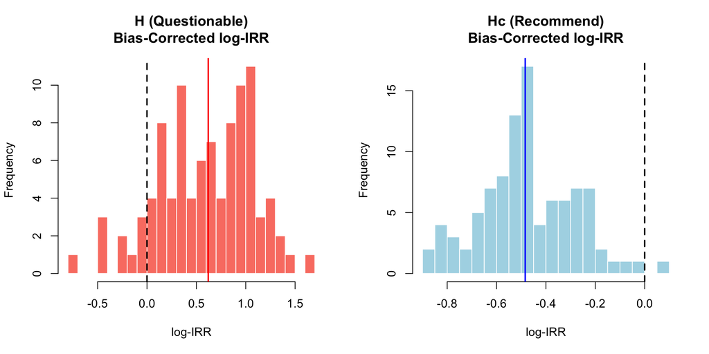

```r
h_bc  <- fs_bc$results$H_biasadj_2[!is.na(fs_bc$results$H_biasadj_2)]
hc_bc <- fs_bc$results$Hc_biasadj_2[!is.na(fs_bc$results$Hc_biasadj_2)]

if (length(h_bc) > 5 && length(hc_bc) > 5) {
  par(mfrow = c(1, 2))

  hist(h_bc, breaks = 25, col = "salmon", border = "white",
       main = "H (Questionable)\nBias-Corrected log-IRR",
       xlab = "log-IRR")
  abline(v = 0, lty = 2, lwd = 2)
  abline(v = median(h_bc), col = "red", lwd = 2)

  hist(hc_bc, breaks = 25, col = "lightblue", border = "white",
       main = "Hc (Recommend)\nBias-Corrected log-IRR",
       xlab = "log-IRR")
  abline(v = 0, lty = 2, lwd = 2)
  abline(v = median(hc_bc), col = "blue", lwd = 2)

  par(mfrow = c(1, 1))
}
```

# 8 Cox vs. Poisson-Offset Comparison

## 8.1 Run Cox Reference

```r
t0 <- proc.time()

fs_cox <- forestsearch(
  df.analysis,
  confounders.name = confounders.name,
  conf_force       = c("er <= 0"),
  outcome.name     = outcome.name.surv,
  event.name       = event.name,
  treat.name       = treat.name,
  id.name          = id.name,
  hr.threshold           = 1.25,
  hr.consistency         = 1.0,
  pconsistency.threshold = 0.80,
  stop_threshold         = 0.80,
  sg_focus             = "hr",
  max_subgroups_search = 3,
  use_twostage         = TRUE,
  use_grf              = TRUE,
  return_selected_cuts_only = TRUE,
  use_lasso            = TRUE,
  cut_type             = "default",
  dmin.grf             = 12,          # RMST scale (months) for survival
  maxk = 2, n.min = 60, d0.min = 12, d1.min = 12,
  fs.splits = 100,
  parallel_args = par_args,
  details = FALSE, plot.sg = FALSE
)
plan("sequential")
timings$cox <- (proc.time() - t0)["elapsed"]
```

```r
fs_bc_cox <- forestsearch_bootstrap_dofuture(
  fs.est     = fs_cox,
  nb_boots   = NB,
  details    = FALSE,
  parallel_args = par_args
)
plan("sequential")
```

## 8.2 Side-by-Side Results

```r
cat("=" |> rep(70) |> paste(collapse = ""), "\n")
cat("GBSG Subgroup Identification: Cox vs. Poisson-Offset\n")
```

```
#> GBSG Subgroup Identification: Cox vs. Poisson-Offset
```

```r
cat("=" |> rep(70) |> paste(collapse = ""), "\n\n")
cat(sprintf("%-25s  %-25s  %-25s\n", "", "Cox (survival)", "Poisson (GLM)"))
```

```
#>                            Cox (survival)             Poisson (GLM)
```

```r
cat("-" |> rep(70) |> paste(collapse = ""), "\n")
cat(sprintf("%-25s  %-25s  %-25s\n", "Subgroup",
    paste(fs_cox$sg.harm, collapse = " & "),
    paste(fs_pois$sg.harm, collapse = " & ")))
```

```
#> Subgroup                   {er <= 0} & {size <= 35}   {er <= 0} & {size <= 35}
```

```r
cat(sprintf("%-25s  %-25s  %-25s\n", "N(harm) / N(benefit)",
    paste(sum(fs_cox$df.est$treat.recommend == 0), "/",
          sum(fs_cox$df.est$treat.recommend == 1)),
    paste(sum(fs_pois$df.est$treat.recommend == 0), "/",
          sum(fs_pois$df.est$treat.recommend == 1))))
```

```
#> N(harm) / N(benefit)       61 / 625                   61 / 625
```

```r
cat("-" |> rep(70) |> paste(collapse = ""), "\n")
cat(sprintf("%-25s  %-25s  %-25s\n", "H raw",
    fs_bc_cox$SG_CIs$H_raw, fs_bc$SG_CIs$H_raw))
```

```
#> H raw                      2.54 (1.25,5.17)           2.25 (1.13,4.5)
```

```r
cat(sprintf("%-25s  %-25s  %-25s\n", "H bias-corrected",
    fs_bc_cox$SG_CIs$H_bc, fs_bc$SG_CIs$H_bc))
```

```
#> H bias-corrected           1.97 (0.64,6.06)           1.82 (0.69,4.77)
```

```r
cat(sprintf("%-25s  %-25s  %-25s\n", "Hc raw",
    fs_bc_cox$SG_CIs$Hc_raw, fs_bc$SG_CIs$Hc_raw))
```

```
#> Hc raw                     0.61 (0.47,0.79)           0.62 (0.48,0.8)
```

```r
cat(sprintf("%-25s  %-25s  %-25s\n", "Hc bias-corrected",
    fs_bc_cox$SG_CIs$Hc_bc, fs_bc$SG_CIs$Hc_bc))
```

```
#> Hc bias-corrected          0.61 (0.46,0.81)           0.62 (0.48,0.81)
```

```r
cat("-" |> rep(70) |> paste(collapse = ""), "\n")
```

## 8.3 Comparative Estimates Table

```r
cat("=== Cox ===\n")
```

```
#> === Cox ===
```

```r
res_cox <- sg_tables(fs_cox, ndecimals = 3, which_df = "est")
res_cox$tab_estimates
```

**Treatment Effect Estimates**

Training data estimates

| Subgroup | n | n1 | events | m1 | m0 | RMST | HR (95% CI) |
| --- | --- | --- | --- | --- | --- | --- | --- |
| ITT | 686 (100.0%) | 246 (35.9%) | 299 (43.6%) | 66.3 | 50.2 | 7.8 | 0.69 (0.54, 0.89) |
| Questionable<sup>1</sup> | 61 (8.9%) | 23 (37.7%) | 34 (55.7%) | 18.5 | 48 | -19 | 2.54 (1.25, 5.17) |
| Recommend | 625 (91.1%) | 223 (35.7%) | 265 (42.4%) | 66.7 | 52.2 | 9.6 | 0.61 (0.47, 0.79) |

<sup>1</sup> **Identified subgroup** : {er <= 0} & {size <= 35}

```r
cat("\n=== Poisson-Offset (GLM) ===\n")
```

```
#>
#> === Poisson-Offset (GLM) ===
```

```r
res_tabs$tab_estimates
```

**Treatment Effect Estimates**

Training data estimates

| Subgroup | n | n1 | Rate(C) | Rate(T) | IRR (95% CI) |
| --- | --- | --- | --- | --- | --- |
| ITT | 686 (100.0%) | 246 (35.9%) | 46.6% | 38.2% | 0.70 (0.55, 0.89) |
| Questionable<sup>1</sup> | 61 (8.9%) | 23 (37.7%) | 50.0% | 65.2% | 2.25 (1.13, 4.50) |
| Recommend | 625 (91.1%) | 223 (35.7%) | 46.3% | 35.4% | 0.62 (0.48, 0.80) |

<sup>1</sup> **Identified subgroup** : {er <= 0} & {size <= 35}

# 9 Summary and Interpretation

## 9.1 Key Findings

```r
cat("=" |> rep(60) |> paste(collapse = ""), "\n")
cat("FORESTSEARCH GLM EXTENSION — ANALYSIS SUMMARY\n")
```

```
#> FORESTSEARCH GLM EXTENSION — ANALYSIS SUMMARY
```

```r
cat("=" |> rep(60) |> paste(collapse = ""), "\n\n")
cat("Dataset: GBSG (N =", nrow(df.analysis), ")\n")
```

```
#> Dataset: GBSG (N = 686 )
```

```r
cat("Outcome type: Binary (event indicator)\n")
```

```
#> Outcome type: Binary (event indicator)
```

```r
cat("Effect measure: Incidence Rate Ratio (IRR)\n")
```

```
#> Effect measure: Incidence Rate Ratio (IRR)
```

```r
cat("Offset: Follow-up time (months)\n\n")
```

```
#> Offset: Follow-up time (months)
```

```r
cat("ITT Analysis:\n")
```

```
#> ITT Analysis:
```

```r
cat("  Cox HR (95% CI):   ", round(exp(coef(cox_itt)), 3),
    sprintf("(%.3f, %.3f)\n",
            exp(confint(cox_itt))[1], exp(confint(cox_itt))[2]))
```

```
#>   Cox HR (95% CI):    0.695 (0.544, 0.888)
```

```r
cat("  Poisson IRR (95% CI):", round(exp(coef(pois_itt)["hormon"]), 3),
    sprintf("(%.3f, %.3f)\n",
            exp(confint(pois_itt)["hormon", 1]),
            exp(confint(pois_itt)["hormon", 2])))
```

```
#>   Poisson IRR (95% CI): 0.701 (0.547, 0.891)
```

```r
cat("\nIdentified Subgroup (H):\n")
```

```
#>
#> Identified Subgroup (H):
```

```r
cat("  Definition:", paste(fs_pois$sg.harm, collapse = " & "), "\n")
```

```
#>   Definition: {er <= 0} & {size <= 35}
```

```r
cat("  Size:", sum(fs_pois$df.est$treat.recommend == 0),
    sprintf("(%.1f%%)\n", 100 * mean(fs_pois$df.est$treat.recommend == 0)))
```

```
#>   Size: 61 (8.9%)
```

```r
cat("  IRR (unadjusted):", fs_bc$SG_CIs$H_raw, "\n")
```

```
#>   IRR (unadjusted): 2.25 (1.13,4.5)
```

```r
cat("  IRR (bias-corrected):", fs_bc$SG_CIs$H_bc, "\n")
```

```
#>   IRR (bias-corrected): 1.82 (0.69,4.77)
```

```r
cat("\nComplement Subgroup (Hc):\n")
```

```
#>
#> Complement Subgroup (Hc):
```

```r
cat("  Size:", sum(fs_pois$df.est$treat.recommend == 1),
    sprintf("(%.1f%%)\n", 100 * mean(fs_pois$df.est$treat.recommend == 1)))
```

```
#>   Size: 625 (91.1%)
```

```r
cat("  IRR (unadjusted):", fs_bc$SG_CIs$Hc_raw, "\n")
```

```
#>   IRR (unadjusted): 0.62 (0.48,0.8)
```

```r
cat("  IRR (bias-corrected):", fs_bc$SG_CIs$Hc_bc, "\n")
```

```
#>   IRR (bias-corrected): 0.62 (0.48,0.81)
```

```r
cat("\nAgreement:\n")
```

```
#>
#> Agreement:
```

```r
cat("  Both paths identify same subgroup:",
    identical(sort(fs_cox$sg.harm), sort(fs_pois$sg.harm)), "\n")
```

[output not shown]

## 9.2 Clinical Interpretation

The IRR estimates track the Cox HRs closely, with the expected slight attenuation due to the non-constant baseline hazard in the GBSG data. The bias-corrected IRR provides a conservative estimate that accounts for selection-induced optimism.

## 9.3 Computational Timing

```r
timings$total <- (proc.time() - t_vignette_start)["elapsed"]

timing_df <- data.frame(
  Analysis = c("GRF (Cox)", "ForestSearch (Poisson)", "Bootstrap (Poisson)",
               "Cox Reference", "Total"),
  Seconds = c(
    timings$grf_cox,
    timings$forestsearch,
    timings$bootstrap,
    timings$cox,
    timings$total
  )
)
timing_df$Minutes <- timing_df$Seconds / 60

gt(timing_df) |>
  tab_header(title = "Computational Timing") |>
  fmt_number(columns = c(Seconds, Minutes), decimals = 1) |>
  cols_label(
    Analysis = "Component",
    Seconds = "Time (sec)",
    Minutes = "Time (min)"
  )
```

Computational Timing

| Component | Time (sec) | Time (min) |
| --- | --- | --- |
| GRF (Cox) | 0.2 | 0.0 |
| ForestSearch (Poisson) | 1.1 | 0.0 |
| Bootstrap (Poisson) | 153.0 | 2.5 |
| Cox Reference | 1.2 | 0.0 |
| Total | 308.1 | 5.1 |

# 10 References

León LF, Jemielita T, Guo Z, Marceau West R, Anderson KM (2024). “Exploratory subgroup identification in the heterogeneous Cox model: A relatively simple procedure.” *Statistics in Medicine*. DOI: 10.1002/sim.10163